# A map of the Divvy stations in Chicago

Peter Carbonetto

**Reproducibility report:**

Results last updated on 2018-02-28

These results were generated with revision [d10090c](https://github.com/NA/tree/d10090c8e6a5f26b5fa6a5069bd06c5e60f26c78)

✔ **SUCCESS:** The R Markdown file is up-to-date

**Click here to see past versions of the R Markdown file:**

| commit | author | when |
| --- | --- | --- |
| [5c4fd93e404656627821f10327cd39ba6e331f58](https://github.com/NA/blob/5c4fd93e404656627821f10327cd39ba6e331f58/analysis/station-map.Rmd) | Peter Carbonetto | 2017-06-29 16:47:27 |
| [67b8d2bbfd5a863bea571a9c8d36903b86c8a395](https://github.com/NA/blob/67b8d2bbfd5a863bea571a9c8d36903b86c8a395/analysis/station-map.Rmd) | Peter Carbonetto | 2017-07-04 12:03:07 |
| [8113086cfd2d26c86e02e9047804eb7bcb17bc62](https://github.com/NA/blob/8113086cfd2d26c86e02e9047804eb7bcb17bc62/analysis/station-map.Rmd) | Peter Carbonetto | 2017-07-05 13:03:30 |
| [96f2db43a65ee5e1d81670016e3262daa0ca0835](https://github.com/NA/blob/96f2db43a65ee5e1d81670016e3262daa0ca0835/analysis/station-map.Rmd) | Peter Carbonetto | 2017-07-05 13:08:41 |
| [f7da4f672203b8b3fdafc2ac2024cbf6405e055c](https://github.com/NA/blob/f7da4f672203b8b3fdafc2ac2024cbf6405e055c/analysis/station-map.Rmd) | Peter Carbonetto | 2017-07-07 13:09:11 |
| [e4ba03348a35b6432945764452be471807e478ae](https://github.com/NA/blob/e4ba03348a35b6432945764452be471807e478ae/analysis/station-map.Rmd) | Peter Carbonetto | 2017-07-07 15:34:30 |
| [6d02ffc0b43bde32d70d2912d46b951034d319ae](https://github.com/NA/blob/6d02ffc0b43bde32d70d2912d46b951034d319ae/analysis/station-map.Rmd) | Peter Carbonetto | 2017-07-13 12:47:51 |
| [6b9ddf1669eaae0911b0940de25d3b8c62d1f30f](https://github.com/NA/blob/6b9ddf1669eaae0911b0940de25d3b8c62d1f30f/analysis/station-map.Rmd) | Peter Carbonetto | 2017-08-02 07:16:30 |
| [9463eb61ba20c8f6a1de8c6928ac99e2b4c282bd](https://github.com/NA/blob/9463eb61ba20c8f6a1de8c6928ac99e2b4c282bd/analysis/station-map.Rmd) | Peter Carbonetto | 2017-11-16 15:38:06 |
| [d10090c8e6a5f26b5fa6a5069bd06c5e60f26c78](https://github.com/NA/blob/d10090c8e6a5f26b5fa6a5069bd06c5e60f26c78/analysis/station-map.Rmd) | Peter Carbonetto | 2018-02-28 16:30:40 |

✔ **SUCCESS:** This analysis was run with the seed 12345

✔ **SUCCESS:** The session information was recorded at the end of the analysis

In this analysis, I will use the Divvy trip and station data to generate a map of Chicago.

I begin by loading a few packages, as well as some additional functions I wrote for this project.

```r
library(data.table)
library(ggplot2)
source("../code/functions.R")
```

## Read the data

As before, I use function `read.divvy.data` to read the trip and station data from the CSV files.

```r
divvy <- read.divvy.data()
# Reading station data from ../data/Divvy_Stations_2016_Q4.csv.
# Reading trip data from ../data/Divvy_Trips_2016_Q1.csv.
# Reading trip data from ../data/Divvy_Trips_2016_04.csv.
# Reading trip data from ../data/Divvy_Trips_2016_05.csv.
# Reading trip data from ../data/Divvy_Trips_2016_06.csv.
# Reading trip data from ../data/Divvy_Trips_2016_Q3.csv.
# Reading trip data from ../data/Divvy_Trips_2016_Q4.csv.
# Preparing Divvy data for analysis in R.
# Converting dates and times.
```

## Get total number of departures by station

I use the trip data to get the total number of departures by station. From these data, I create a “departures” column.

```r
divvy$stations <-
  cbind(divvy$stations,
    data.frame(departures = as.vector(table(divvy$trips$from_station_id))))
summary(divvy$stations$departures)
#    Min. 1st Qu.  Median    Mean 3rd Qu.    Max.
#       1     557    3058    6188    9029   90042
```

## Create a Divvy stations map

A plot of the Divvy stations by geographic location (latitude and longitude) traces the outlines of the City of Chicago and the Lake Michigan shore. Further, the location of the downtown is apparent by scaling the area of each circle by the number of trips.

The University of Chicago Divvy station is highlighted in red.

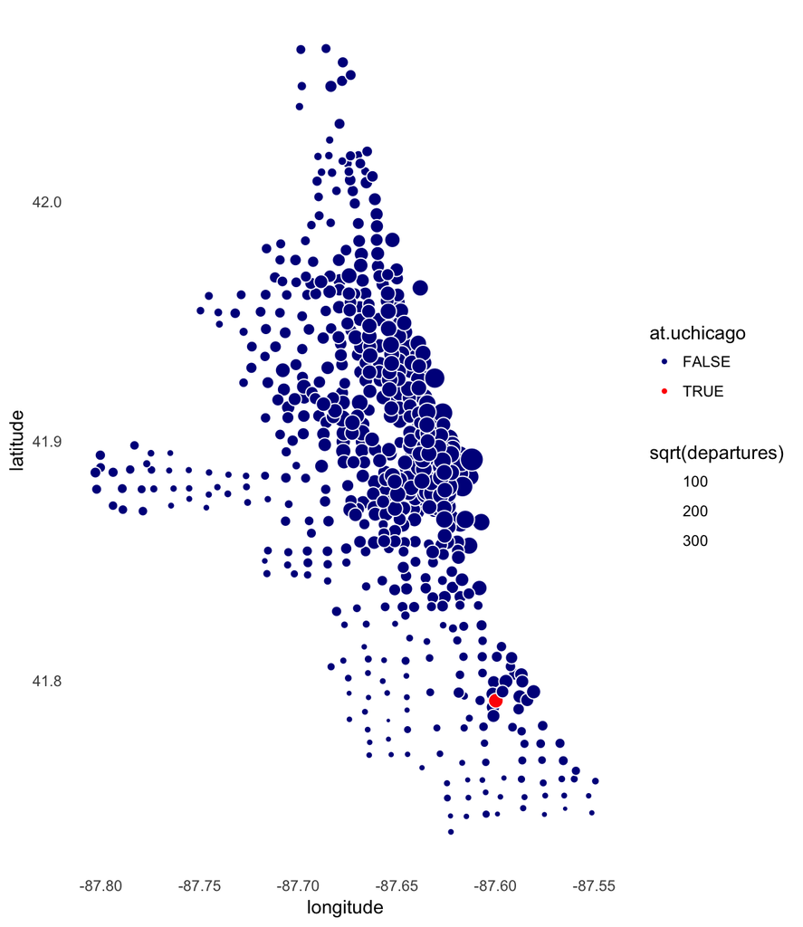

```r
divvy$stations <-
  transform(divvy$stations,
            at.uchicago = (name == "University Ave & 57th St"))
ggplot(divvy$stations,aes(x    = longitude,
                          y    = latitude,
                          fill = at.uchicago,
                          size = sqrt(departures))) +
  geom_point(shape = 21,color = "white") +
  scale_fill_manual(values = c("darkblue","red")) +
  theme_minimal() +
  theme(panel.grid.major = element_blank(),
        panel.grid.minor = element_blank())
```

## Session information

This is the version of R and the packages that were used to generate these results.

```r
sessionInfo()
# R version 3.4.3 (2017-11-30)
# Platform: x86_64-apple-darwin15.6.0 (64-bit)
# Running under: macOS High Sierra 10.13.3
#
# Matrix products: default
# BLAS: /Library/Frameworks/R.framework/Versions/3.4/Resources/lib/libRblas.0.dylib
# LAPACK: /Library/Frameworks/R.framework/Versions/3.4/Resources/lib/libRlapack.dylib
#
# locale:
# [1] en_US.UTF-8/en_US.UTF-8/en_US.UTF-8/C/en_US.UTF-8/en_US.UTF-8
#
# attached base packages:
# [1] stats     graphics  grDevices utils     datasets  methods   base
#
# other attached packages:
# [1] ggplot2_2.2.1       data.table_1.10.4-3 repdoc_0.0.0.9000
# [4] workflowr_0.10.2    rmarkdown_1.8
#
# loaded via a namespace (and not attached):
#  [1] Rcpp_0.12.15      knitr_1.20        magrittr_1.5
#  [4] munsell_0.4.3     colorspace_1.3-2  debugme_1.1.0
#  [7] R6_2.2.2          rlang_0.2.0.9000  plyr_1.8.4
# [10] stringr_1.3.0     highr_0.6         tools_3.4.3
# [13] grid_3.4.3        gtable_0.2.0      R.oo_1.21.0
# [16] git2r_0.21.0      htmltools_0.3.6   lazyeval_0.2.1
# [19] yaml_2.1.17       rprojroot_1.3-2   digest_0.6.15
# [22] assertthat_0.2.0  tibble_1.4.2      crayon_1.3.4
# [25] callr_2.0.2.9001  R.utils_2.6.0     fs_1.1.0
# [28] clisymbols_1.2.0  evaluate_0.10.1   labeling_0.3
# [31] stringi_1.1.6     pillar_1.2.1      compiler_3.4.3
# [34] scales_0.5.0      backports_1.1.2   R.methodsS3_1.7.1
```

This reproducible [R Markdown](http://rmarkdown.rstudio.com) analysis was created with repdoc